# Practice Midterm 2

2025-03-06

```r
install.packages("fpp2")
library(fpp2)
```

```r
library(forecast)
library(TTR)
library(ggplot2)
library(knitr)

data("arrivals")
str(arrivals)
```

```
##  Time-Series [1:127, 1:4] from 1981 to 2012: 14.76 9.32 10.17 19.51 17.12 ...
##  - attr(*, "dimnames")=List of 2
##   ..$ : NULL
##   ..$ : chr [1:4] "Japan" "NZ" "UK" "US"
```

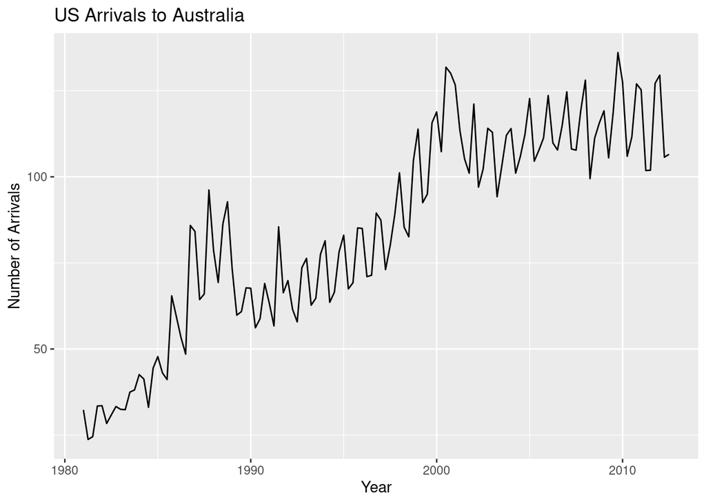

```r
us_arrivals <- arrivals[, "US"]

autoplot(us_arrivals) + ggtitle("US Arrivals to Australia") + ylab("Number of Arrivals") + xlab("Year")
```

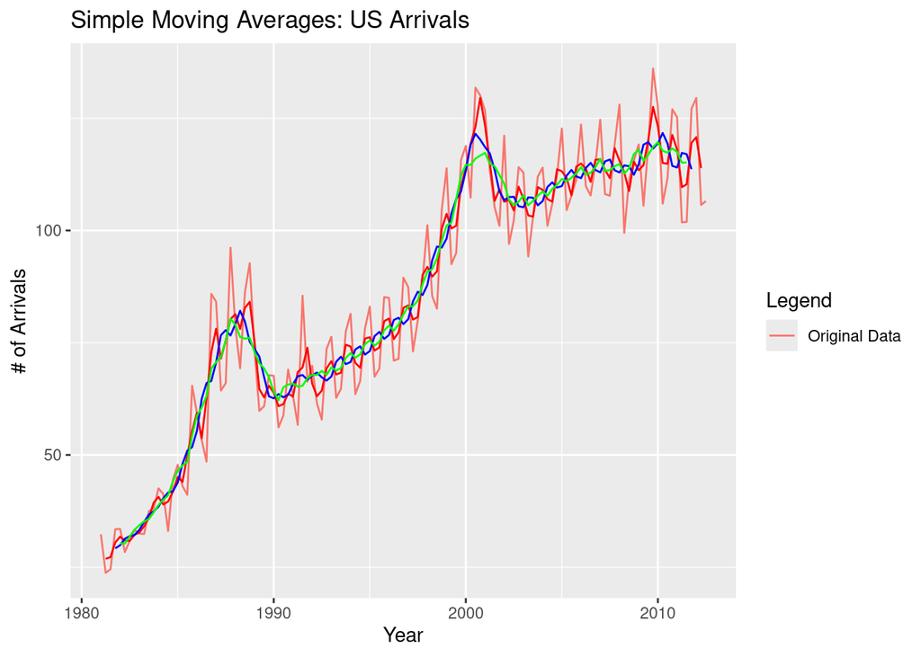

```r
sma3 <- ma(us_arrivals, order=3)
sma6 <- ma(us_arrivals, order=6)
sma9 <- ma(us_arrivals, order=9)

autoplot(us_arrivals, series="Original Data") +
  autolayer(sma3, series="SMA (3)", color="red") +
  autolayer(sma6, series="SMA (6)", color="blue") +
  autolayer(sma9, series="SMA (9)", color="green") +
  ggtitle("Simple Moving Averages: US Arrivals") +
  xlab("Year") + ylab("# of Arrivals") +
  guides(color=guide_legend(title="Legend"))
```

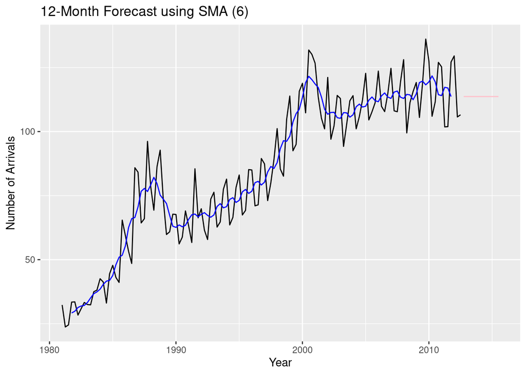

```r
forecastsma <- naive(tail(sma6, 12), h=12)

autoplot(us_arrivals) +
  autolayer(sma6, series="SMA (6)", color="blue") +
  autolayer(forecastsma$mean, series="Forecast (SMA 6)", color="pink") +
  ggtitle("12-Month Forecast using SMA (6)") +
  xlab("Year") + ylab("Number of Arrivals") +
  guides(color=guide_legend(title="Legend"))
```

I used SMA of order 6 for the forecast above, because it provides a balance between smoothing and also accounting for the trends.

My observation of the plot as the moving average order goes up is that the line becomes smoother and has much less fluctuations that show trends and seasonality. Although noise is taken away as the SMA order goes up, there is over-smoothing.

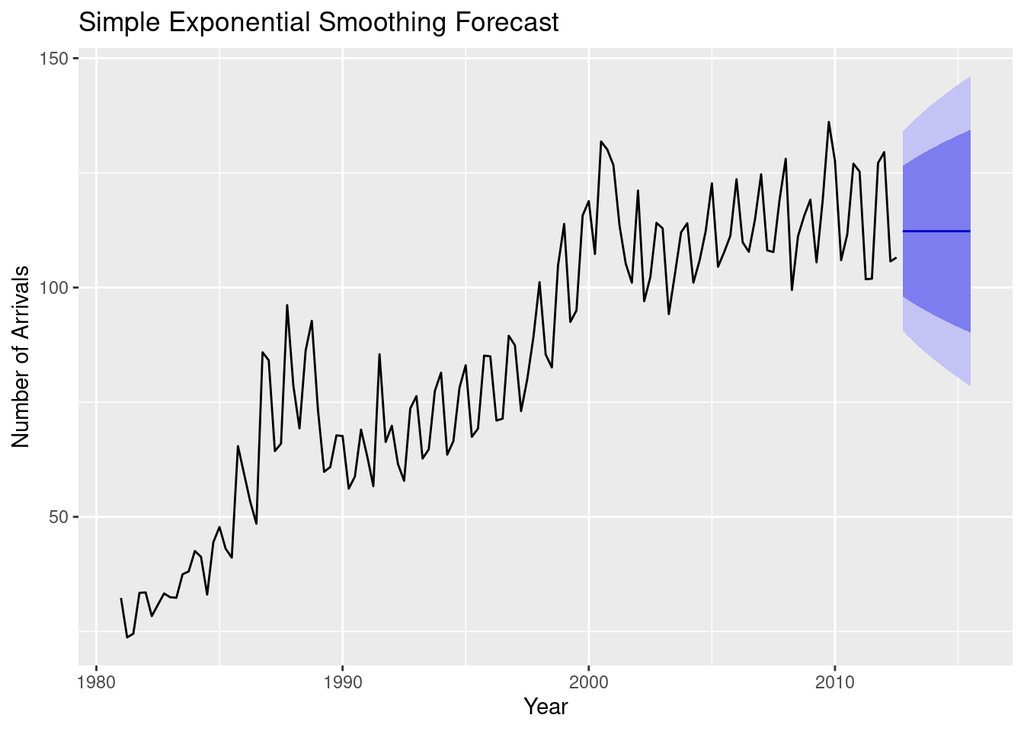

```r
sesmodel <- ses(us_arrivals, h=12)

autoplot(sesmodel) +
  ggtitle("Simple Exponential Smoothing Forecast") +
  xlab("Year") + ylab("Number of Arrivals")
```

```r
alpha <- sesmodel$model$par[1]

initial <- sesmodel$model$states[1]

sigma <- sqrt(sesmodel$model$sigma2)

cat("Alpha (α):", alpha, "\n")
```

```
## Alpha (α): 0.358286
```

```r
cat("Initial State:", initial, "\n")
```

```
## Initial State: 29.2852
```

```r
cat("Sigma (σ):", sigma, "\n")
```

```
## Sigma (σ): 11.10216
```

Alpha is the smoothing parameter and determines how much weight is placed on the most recent observation (36%). Because alpha is closer to 0 (0.358286), we can determine that it is a smoother forecast which relies more on past observations and is slower to adapt to trends.

The initial value is the estimated starting value for exponential smoothing. In this case, the initial state is 29.2852, meaning that the initial estimate was 29.2852 arrivals prior to taking the data into account.

Sigma is the standard deviation of the residuals in the forecast, so in this case the forecast deviates by 11.10216 arrivals from the actual values.

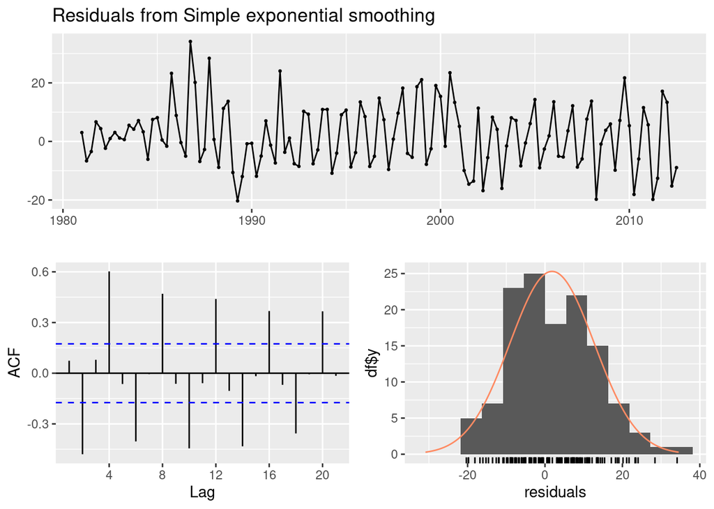

```
##
##  Ljung-Box test
##
## data:  Residuals from Simple exponential smoothing
## Q* = 133.08, df = 8, p-value < 2.2e-16
##
## Model df: 0.   Total lags used: 8
```

```r
checkresiduals(sesmodel)
```

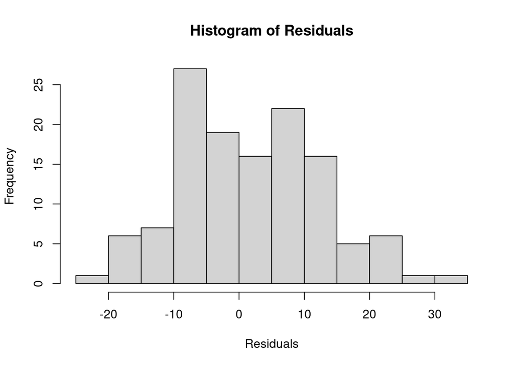

```r
hist(residuals(sesmodel), main="Histogram of Residuals", xlab="Residuals")
```

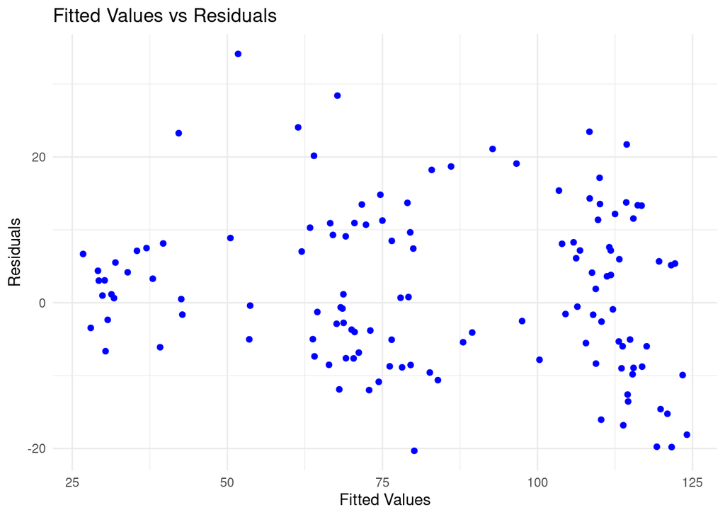

```r
ggplot(data = data.frame(Fitted = fitted(sesmodel), Residuals = residuals(sesmodel)), aes(x = Fitted, y = Residuals)) +
  geom_point(color = "blue") +
  ggtitle("Fitted Values vs Residuals") +
  xlab("Fitted Values") + ylab("Residuals") +
  theme_minimal()
```

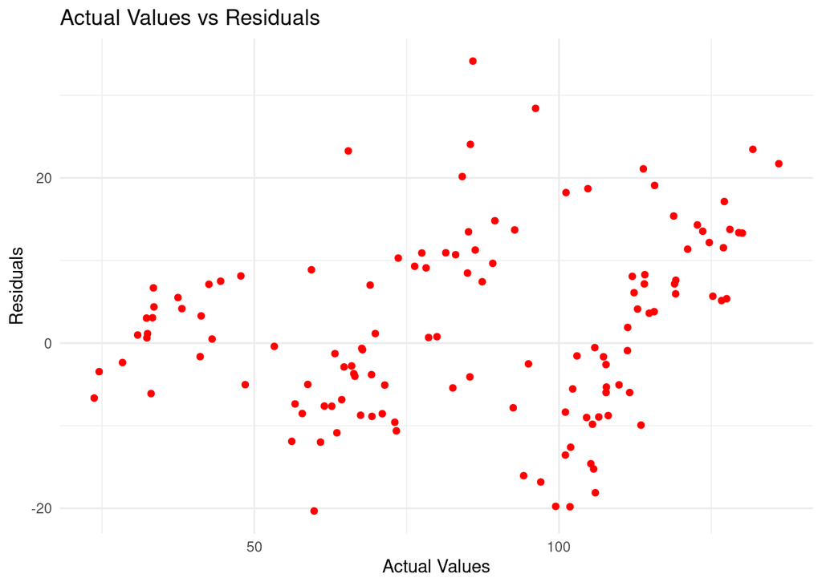

```r
ggplot(data = data.frame(Actuals = us_arrivals, Residuals = residuals(sesmodel)), aes(x = Actuals, y = Residuals)) +
  geom_point(color = "red") +
  ggtitle("Actual Values vs Residuals") +
  xlab("Actual Values") + ylab("Residuals") +
  theme_minimal()
```

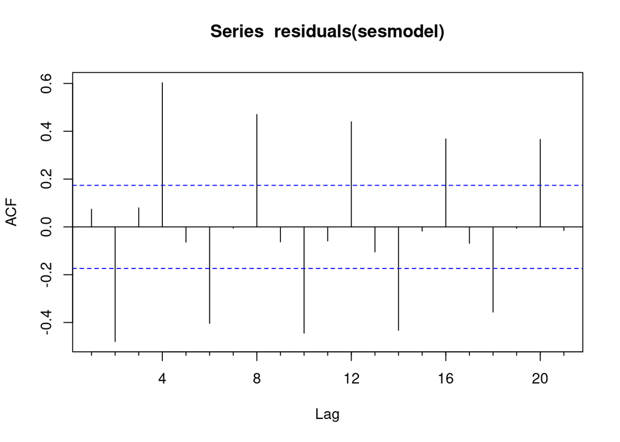

```r
Acf(residuals(sesmodel))
```

```r
accuracy(sesmodel)
```

```
##                   ME     RMSE      MAE      MPE     MAPE    MASE       ACF1
## Training set 1.82391 11.01439 8.931938 1.411919 10.87911 1.21021 0.07390199
```

Residuals plot: Patterns are showing instead of randomness, indicating that SES may not be the best model for the forecasting.

Histogram: Residuals are not normally distributed there is some skewness, showing there is some bias, but relatively closer to normal.

Fitted vs. residuals: Points are bunches together i sections rather being evenly spread, indicating that some trends may not be accounted for.

Actual vs. residuals: There is a pattern overall and the points are increasing, again showing a biased not suitable model.

```r
train_size <- length(us_arrivals) - 12

train_set <- ts(us_arrivals[1:train_size], frequency=frequency(us_arrivals), start=start(us_arrivals))
test_set <- ts(us_arrivals[(train_size+1):length(us_arrivals)], frequency=frequency(us_arrivals), start=time(us_arrivals)[train_size+1])

ses_train <- ses(train_set, h=12)

forecastval <- forecast(ses_train, h=12)

print(forecastval)
```

```
##         Point Forecast     Lo 80    Hi 80    Lo 95    Hi 95
## 2009 Q4       114.4545 100.69562 128.2134 93.41211 135.4969
## 2010 Q1       114.4545  99.72796 129.1810 91.93219 136.9768
## 2010 Q2       114.4545  98.82007 130.0889 90.54370 138.3653
## 2010 Q3       114.4545  97.96208 130.9469 89.23152 139.6775
## 2010 Q4       114.4545  97.14657 131.7624 87.98431 140.9247
## 2011 Q1       114.4545  96.36780 132.5412 86.79328 142.1157
## 2011 Q2       114.4545  95.62120 133.2878 85.65145 143.2575
## 2011 Q3       114.4545  94.90309 134.0059 84.55320 144.3558
## 2011 Q4       114.4545  94.21044 134.6986 83.49388 145.4151
## 2012 Q1       114.4545  93.54072 135.3683 82.46963 146.4394
## 2012 Q2       114.4545  92.89178 136.0172 81.47717 147.4318
## 2012 Q3       114.4545  92.26182 136.6472 80.51372 148.3953
```

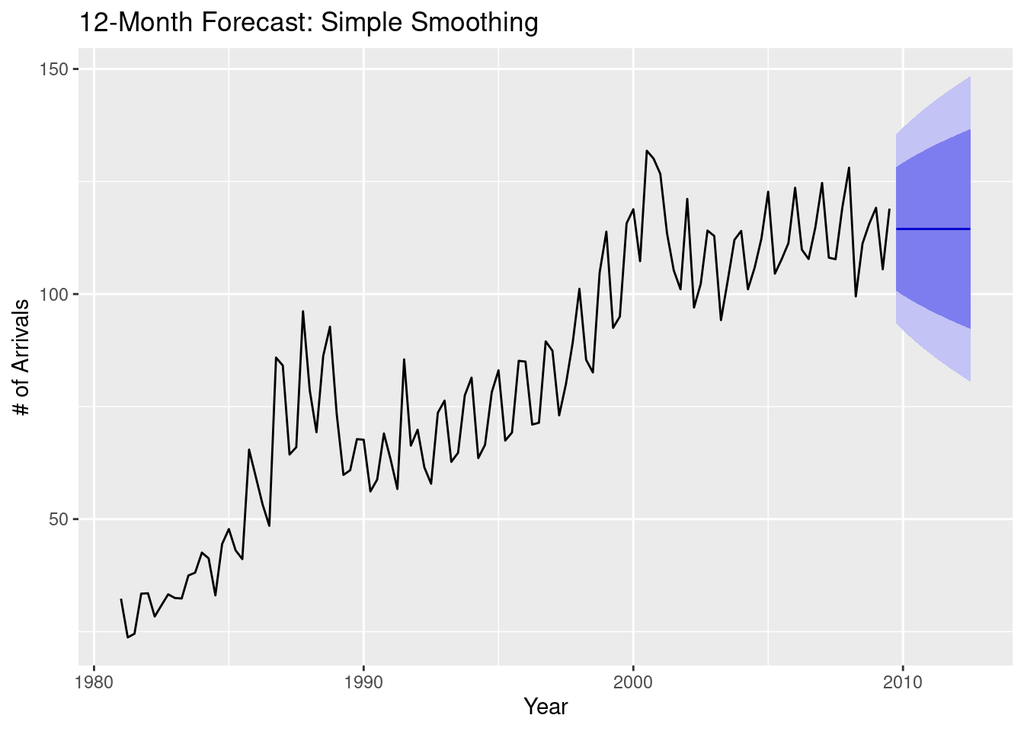

```r
autoplot(forecastval) +
  ggtitle("12-Month Forecast: Simple Smoothing") +
  xlab("Year") + ylab("# of Arrivals")
```

```r
print("Training Accuracy Measures:")
```

```
## [1] "Training Accuracy Measures:"
```

```r
train_accuracy <- accuracy(ses_train$fitted, train_set)
rownames(train_accuracy) <- "Training Set"  # Rename row for clarity
print(train_accuracy)
```

```
##                    ME     RMSE      MAE      MPE     MAPE       ACF1 Theil's U
## Training Set 1.942362 10.64234 8.529049 1.561913 10.86579 0.03814922 0.8969351
```

```r
print("Testing Accuracy Measures:")
```

```
## [1] "Testing Accuracy Measures:"
```

```r
test_accuracy <- accuracy(forecastval$mean, test_set)
rownames(test_accuracy) <- "Testing Set"  # Rename row for clarity
print(test_accuracy)
```

```
##                   ME     RMSE      MAE      MPE     MAPE      ACF1 Theil's U
## Testing Set 2.723249 12.37548 11.58308 1.276394 9.770673 0.1306649 0.7325133
```

```r
forecast_one_year <- tail(forecastval$mean, 1)
print(paste("Predicted Value in a year:", round(forecast_one_year, 2)))
```

```
## [1] "Predicted Value in a year: 114.45"
```

Based on the accuracy measures, SES is performing fairly well, but there are some forecasting errors indicating that a model that takes into account seasonality would be better fit for this data. Overall, SES is better for short-term data without the presence of seasonality- the forecast is essentially a smoothed version continuing on from the current data rather than accounting for trends and seasonality fluctuationss.

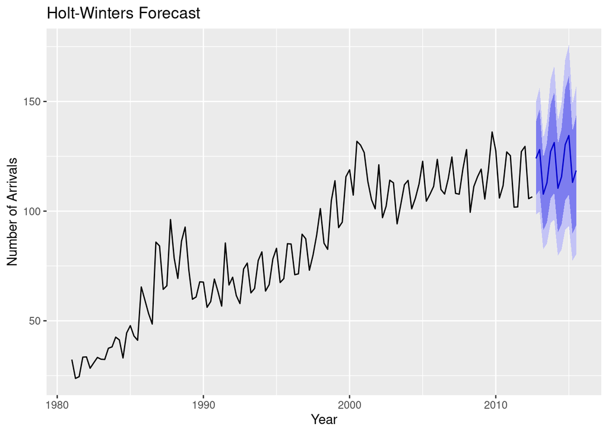

```r
hw <- hw(us_arrivals, seasonal="multiplicative", h=12)

autoplot(hw) +
  ggtitle("Holt-Winters Forecast") +
  xlab("Year") + ylab("Number of Arrivals")
```

```r
alpha <- hw$model$par[1]
beta <- hw$model$par[2]
gamma <- hw$model$par[3]

initiallevel <- hw$model$states[1]
initialtrend <- hw$model$states[2]
initialseasonality <- hw$model$states[3]

sigma <- sqrt(hw$model$sigma2)

cat("Alpha (α):", alpha, "\n")
```

```
## Alpha (α): 0.3709394
```

```r
cat("Beta (β):", beta, "\n")
```

```
## Beta (β): 0.0001000002
```

```r
cat("Gamma (γ):", gamma, "\n")
```

```
## Gamma (γ): 0.003392198
```

```r
cat("Initial Level:", initiallevel, "\n")
```

```
## Initial Level: 28.04083
```

```r
cat("Initial Trend:", initialtrend, "\n")
```

```
## Initial Trend: 29.12435
```

```r
cat("Initial Seasonality:", initialseasonality, "\n")
```

```
## Initial Seasonality: 28.46803
```

```r
cat("Sigma (σ):", sigma, "\n")
```

```
## Sigma (σ): 0.1054427
```

Alpha is the smoothing parameter and determines how much weight is placed on the most recent observation (37%). Because alpha is closer to 0 (0.3709394), we can determine that it is a smoother forecast which relies more on past observations and is slower to adapt to trends.

Beta represents how much weight is given to trend changes, and because it is very small (0.0001), we can see that the model detects minimal trends.

Gamma represents the weight given to seasonality, and because the value is fairly low (0.33%), which shows that there is consistent seasonality.

The initial value is the estimated starting value for exponential smoothing. In this case, the initial state is 28.04083, meaning that the initial estimate was 28.04083 arrivals prior to taking the data into account.

The initial trend estimate is 29.12435, which is used for forecasting future values.

The initial seasonality shows how the first cycle of the seasonal pattern was initialized, and it is 28.46803.

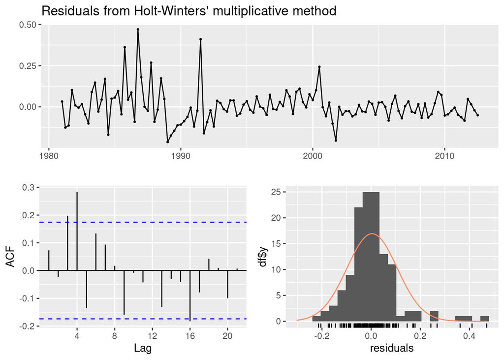

```
##
##  Ljung-Box test
##
## data:  Residuals from Holt-Winters' multiplicative method
## Q* = 22.73, df = 8, p-value = 0.003729
##
## Model df: 0.   Total lags used: 8
```

```r
checkresiduals(hw)
```

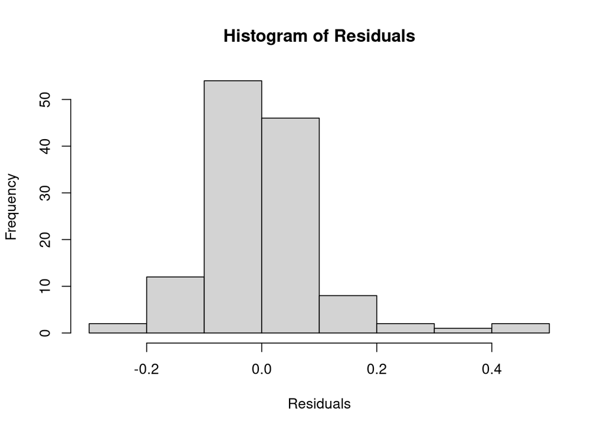

```r
hist(residuals(hw), main="Histogram of Residuals", xlab="Residuals")
```

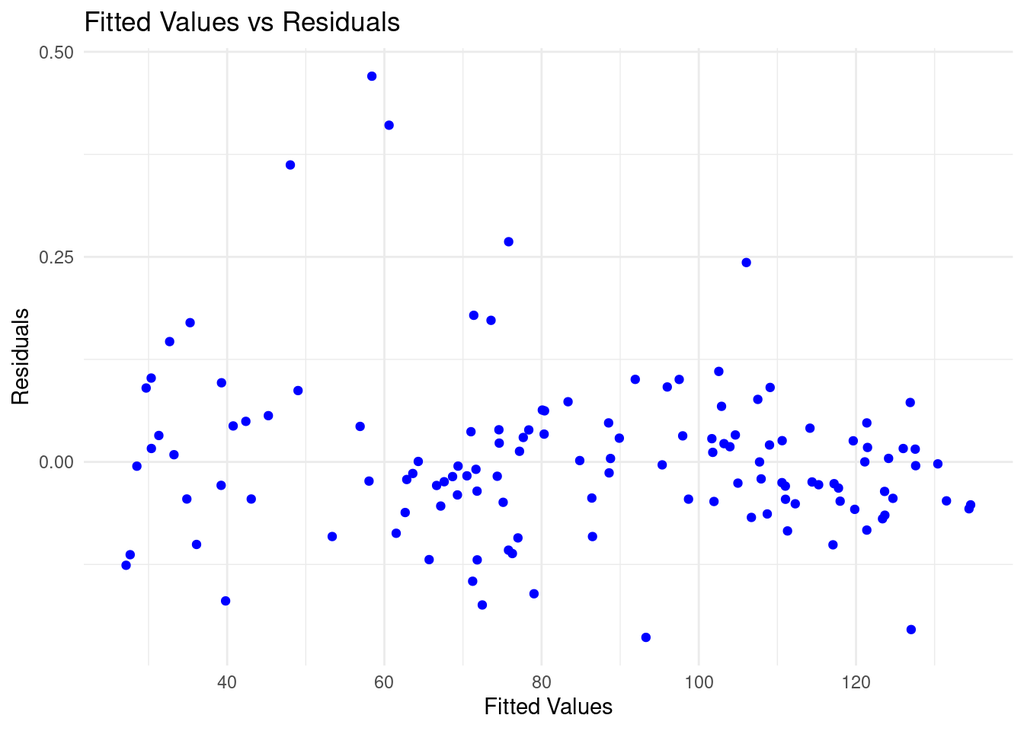

```r
ggplot(data = data.frame(Fitted = fitted(hw), Residuals = residuals(hw)), aes(x = Fitted, y = Residuals)) +
  geom_point(color = "blue") +
  ggtitle("Fitted Values vs Residuals") +
  xlab("Fitted Values") + ylab("Residuals") +
  theme_minimal()
```

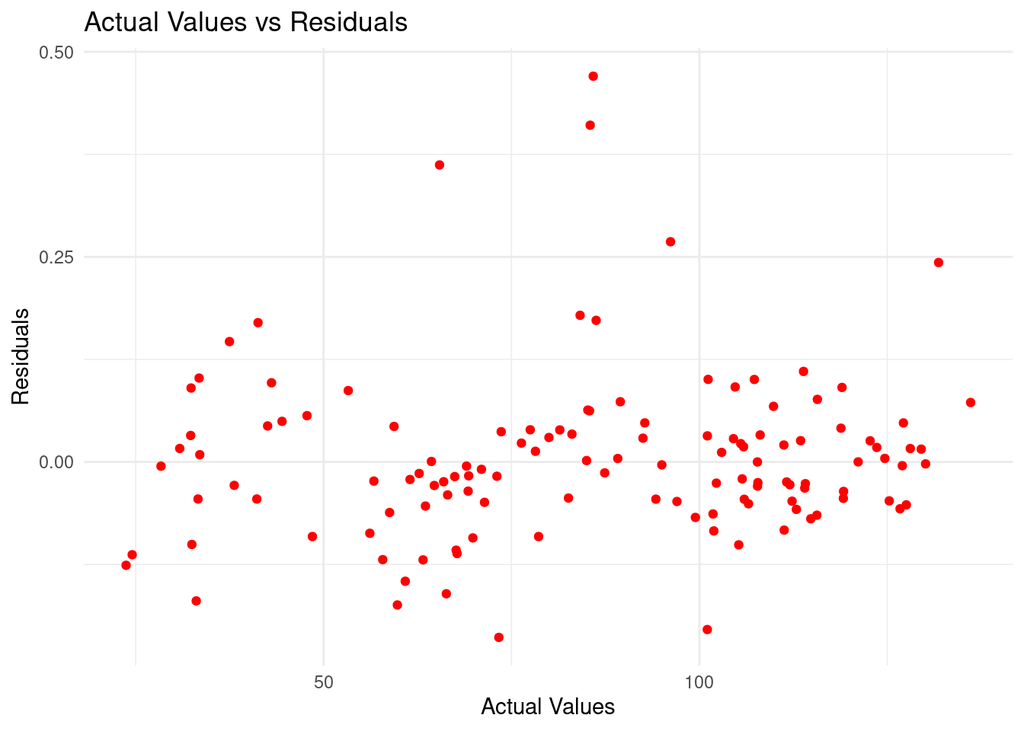

```r
ggplot(data = data.frame(Actuals = us_arrivals, Residuals = residuals(hw)), aes(x = Actuals, y = Residuals)) +
  geom_point(color = "red") +
  ggtitle("Actual Values vs Residuals") +
  xlab("Actual Values") + ylab("Residuals") +
  theme_minimal()
```

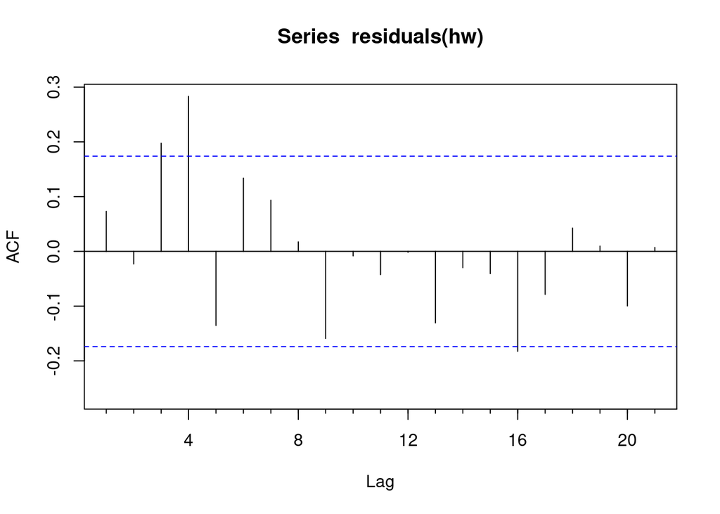

```r
Acf(residuals(hw))
```

```r
accuracy(hw)
```

```
##                     ME    RMSE      MAE        MPE     MAPE      MASE      ACF1
## Training set -0.124104 7.58933 5.322968 -0.5383928 6.702413 0.7212217 0.1617234
```

Residuals plot: There are not many extreme patterns in the residuals, indicating that HW is capturing trends fairly well.

Histogram: There is a pretty normal distribution but slight skewness indicating some underprediction occuring in the model.

Fitted values vs. Residuals: No clear pattern in the points showing that there is no string bias in the model, which is good.

Actual values vs. Residuals: Randomly distributed scatterplot, also showing no major bias.

```r
train_size <- length(us_arrivals) - 12
train_set <- ts(us_arrivals[1:train_size], frequency=frequency(us_arrivals), start=start(us_arrivals))
test_set <- ts(us_arrivals[(train_size+1):length(us_arrivals)], frequency=frequency(us_arrivals), start=time(us_arrivals)[train_size+1])

hw_model <- hw(train_set, seasonal="multiplicative", h=12)
forecasthw <- forecast(hw_model, h=12)

print(forecasthw)
```

```
##         Point Forecast     Lo 80    Hi 80     Lo 95    Hi 95
## 2009 Q4       122.3376 105.35160 139.3235  96.35977 148.3154
## 2010 Q1       130.7672 110.88286 150.6516 100.35672 161.1777
## 2010 Q2       111.5545  93.24656 129.8625  83.55491 139.5541
## 2010 Q3       117.9022  97.23884 138.5656  86.30031 149.5041
## 2010 Q4       125.1981 100.77786 149.6183  87.85058 162.5455
## 2011 Q1       133.8084 106.45925 161.1576  91.98148 175.6353
## 2011 Q2       114.1350  89.79553 138.4746  76.91097 151.3591
## 2011 Q3       120.6151  93.87527 147.3549  79.72005 161.5102
## 2011 Q4       128.0613  97.66135 158.4612  81.56860 174.5539
## 2012 Q1       136.8525 103.33659 170.3684  85.59435 188.1106
## 2012 Q2       116.7180  87.28781 146.1482  71.70840 161.7276
## 2012 Q3       123.3306  91.37090 155.2902  74.45247 172.2087
```

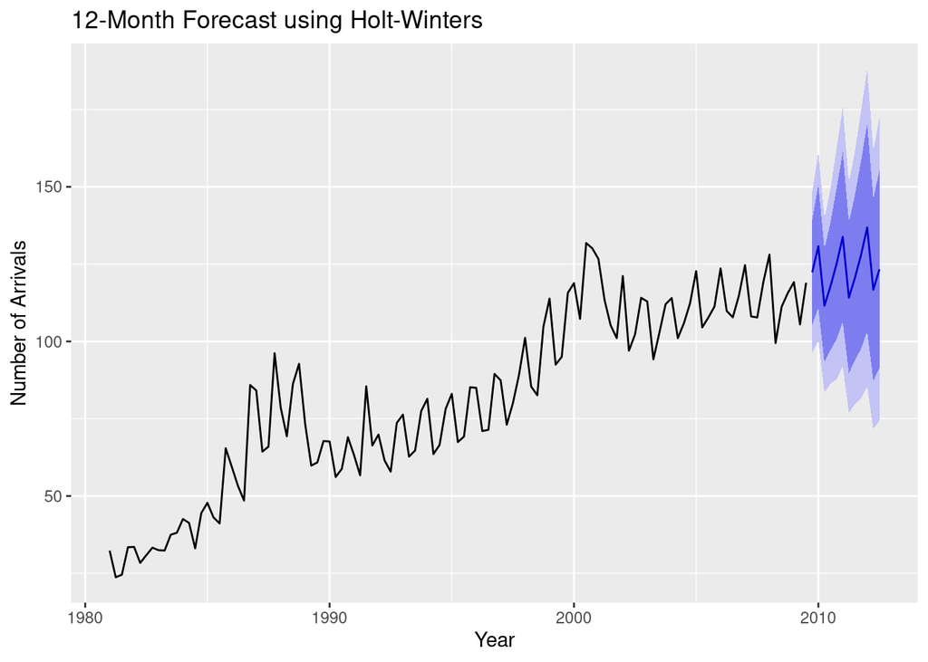

```r
autoplot(forecasthw) +
  ggtitle("12-Month Forecast using Holt-Winters") +
  xlab("Year") + ylab("Number of Arrivals")
```

```r
print("Training Accuracy Measures:")
```

```
## [1] "Training Accuracy Measures:"
```

```r
train_accuracy_hw <- accuracy(hw_model$fitted, train_set)
rownames(train_accuracy_hw) <- "Training Set"
print(train_accuracy_hw)
```

```
##                     ME     RMSE      MAE        MPE     MAPE       ACF1
## Training Set 0.1105256 7.753473 5.244159 -0.2184326 6.907209 0.04371135
##              Theil's U
## Training Set 0.6511006
```

```r
print("Testing Accuracy Measures:")
```

```
## [1] "Testing Accuracy Measures:"
```

```r
test_accuracy_hw <- accuracy(forecasthw$mean, test_set)
rownames(test_accuracy_hw) <- "Testing Set"
print(test_accuracy_hw)
```

```
##                    ME     RMSE      MAE      MPE     MAPE      ACF1 Theil's U
## Testing Set -6.262291 10.43098 8.855686 -5.97719 7.898597 0.1390935 0.6974495
```

```r
forecast_one_year_hw <- tail(forecasthw$mean, 1)
print(paste("Predicted Value in a year:", round(forecast_one_year_hw, 2)))
```

```
## [1] "Predicted Value in a year: 123.33"
```

Based on the accuracy, the Holt-Winters model has minimal errors and indicates good forecast accuracy. To summarize, the HW model captures trends and seasonality that occur in this dataset effectively.

```r
accuracy_table <- data.frame(
  Method = c("SES (Training)", "SES (Testing)", "Holt-Winters (Training)", "Holt-Winters (Testing)"),
  ME = c(1.94, 2.72, 0.11, -6.26),
  RMSE = c(10.64, 12.38, 7.75, 10.43),
  MAE = c(8.53, 11.58, 5.24, 8.85),
  MPE = c(1.56, 1.28, -0.21, -5.97),
  MAPE = c(10.87, 9.77, 6.91, 7.89),
  ACF1 = c(0.038, 0.130, 0.044, 0.139)
)

kable(accuracy_table, caption = "Accuracy Comparison: SES vs. Holt-Winters")
```

Accuracy Comparison: SES vs. Holt-Winters

| Method | ME | RMSE | MAE | MPE | MAPE | ACF1 |
| --- | --- | --- | --- | --- | --- | --- |
| SES (Training) | 1.94 | 10.64 | 8.53 | 1.56 | 10.87 | 0.038 |
| SES (Testing) | 2.72 | 12.38 | 11.58 | 1.28 | 9.77 | 0.130 |
| Holt-Winters (Training) | 0.11 | 7.75 | 5.24 | -0.21 | 6.91 | 0.044 |
| Holt-Winters (Testing) | -6.26 | 10.43 | 8.85 | -5.97 | 7.89 | 0.139 |

Simple Exponential Smoothing (SES): A smoothing technique that emphasizes recent data but does not account for trend or seasonality Pros: Short-term forecasting with data that is fairly stable Cons: Fails to represent seasonality in this dataset

Holt-Winters (HW): A smoothing technique that includes level, trend, and seasonality. Pros: Time series with seasonality & trends that are present Cons: Sensitive to parameter selections and less effective for short-term

The time series shows a clear seasonal pattern and also an upward trend, SES fails to capture the seasonality and has more errors, whereas HW captures seasonality and trends and has fewer errors making it the better forecast model. According to HW, an upward trend will continue over the next year and the next two years, with the seasonal fluctuations.

The ranking would be 1)HW and 2)SES